# Lab 2.2 - Data Transformation

In this lab we will work with data from a survey on the habits of smokers in the United Kingdom. The data come from the National STEM Centre, Large Datasets from stats4schools, https://www.stem.org.uk/resources/elibrary/resource/28452/large-datasets-stats4schools.

The data are in the data folder of the repository. You can load them using

```r
library(tidyverse)
smoking <- read_csv("data/smoking.csv")
```

The variables collected are (the levels they take appear in parentheses):

- `gender`: Gender
- `age`: Age
- `marital_status`: Marital status (Divorced, Married, Separated, Single and Widowed)
- `highest_qualification`: Highest qualification (A Levels, Degree, GCSE/CSE, GCSE/O Level, Higher/Sub Degree, No Qualification, ONC/BTEC and Other/Sub Degree)
- `nationality`: Nationality (British, English, Irish, Scottish, Welsh, Other, Refused and Unknown)
- `ethnicity` : Ethnicity (Asian, Black, Chinese, Mixed, White and Refused Unknown)
- `gross_income`: Gross income (Under 2,600, 2,600 to 5,200, 5,200 to 10,400, 10,400 to 15,600, 15,600 to 20,800, 20,800 to 28,600, 28,600 to 36,400, Above 36,400, Refused and Unknown)
- `region`: Region (London, Midlands & East Anglia, Scotland, South East, South West, The North and Wales)
- `smoke` : Smoker (No and Yes)
- `amt_weekends`: Number of cigarettes per day on weekends
- `amt_weekdays`: Number of cigarettes per day on weekdays
- `type`: Type of cigarettes (Packets, Hand-Rolled, Both/Mainly Packets and Both/Mainly Hand-Rolled)

## Exercise 1

How many observations are there in the dataset for each gender? What proportion of women are smokers? And of men?

## Exercise 2

Select the `amt_weekends` variable, sort it in decreasing order and show the first 10 values. Do the same with `amt_weekdays`; what do you observe?

## Exercise 3

What unique values does the `gross_income` variable take?

Replace the Unknown values with `NA` and compute the unique values of the variable again.

## Exercise 4

Show the last 10 rows of the dataset.

## Exercise 5

What is the mean number of cigarettes per weekday smoked by smokers under 30? And the mean number of cigarettes per weekday smoked by under-30s in general?

**Note**: If you see `NA`, determine the possible origin of those missing values and how to handle them.

## Exercise 6

Compute the mean, median, and standard deviation of cigarettes/day on weekends and on weekdays by age groups less than or equal to 20, 20-30, …, >90. Summarize the conclusions drawn from the results observed.

*Note*: Create a new variable called `decade` using the `case_when` function. The levels of this variable must be `"<=20","20-30","30-40", "40-50", "50-60", "60-70", "70-80", "80-90", ">90"`.

## Exercise 7

Sort the different ethnicities in decreasing order of the proportion of smokers in the sample. Exclude those observations with unknown or undeclared ethnicity.

## Exercise 8

Reproduce the following plot. Draw some conclusions.

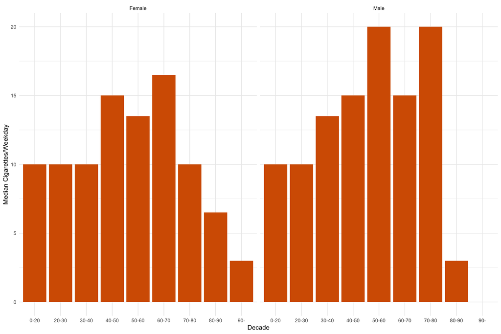

## Exercise 9

Which types of tobacco are most popular in the different gross income brackets? And in the different age brackets?

*Note*: use the decade variable created earlier

## Exercise 10

What is the difference between these two pieces of code?

```r
smoking %>% count(gender, smoke) %>% mutate(prop=n/sum(n))
```

```r
smoking %>% group_by(gender, smoke) %>% summarise(n=n()) %>%
  mutate(prop=n/sum(n))
```

## Exercise 11

Among people who are not married, how many cigarettes/weekday are smoked on average by level of education?

## Exercise 12

On many occasions, in the presence of missing values, it is useful to replace them with a value. This process is known as imputation. One of the most common techniques for imputing categorical variables consists of replacing the missing values with the most likely value in a certain segment of the population (the mode).

For example, we can replace the unknown or undeclared values of the `ethnicity` variable with the most frequent ethnicity in the data, and assume that the error rate will be small. A perhaps smarter strategy is to replace the unknown or undeclared values of the `ethnicity` variable with the most prevalent ethnicity in the corresponding nation. In this exercise, you have to do the latter. To do so, use the following function to compute the mode.

```r
calc_mode <- function(x){

  x <- x[!x %in% c("Refused", "Unkown")]
  distinct_values <- unique(x)
  distinct_tabulate <- tabulate(match(x, distinct_values))
  distinct_values[which.max(distinct_tabulate)]

}
```

*Note*: Exclude the observations with unknown or undeclared nationality. What happens if you include them?